# Value at Risk (VaR) — Historical Method (Clean Notebook)

This notebook computes **Value at Risk (VaR)** using the **Historical (Non‑Parametric)** approach.

## What you will do

- Choose a stock ticker (e.g., `AAPL`, `MSFT`, `NVDA`).
- Download daily adjusted close prices.
- Compute daily returns.
- Estimate VaR using the **empirical quantile** of historical returns:
  - **Daily VaR**
  - **Horizon VaR** (e.g., 30‑day) using **rolling compounded returns** (historically consistent).

## Key idea (Historical VaR)

Historical VaR does **not** assume Normality. It uses the return distribution observed in the sample. For confidence level (c), the VaR threshold is the ((1-c)) lower tail quantile of returns.

> **Convention used here:** VaR is reported as a **negative return** (a loss threshold). Dollar VaR is therefore typically negative as well.

```python
# =========================
# 0) Imports
# =========================
import numpy as np
import pandas as pd
import yfinance as yf
import matplotlib.pyplot as plt

pd.set_option("display.width", 140)
pd.set_option("display.max_columns", 50)
```

```
Matplotlib is building the font cache; this may take a moment.
```

## 1) Inputs

- **TICKER**: stock symbol
- **START, END**: sample window
- **CONF_LEVELS**: VaR confidence levels
- **INITIAL_INV**: portfolio value (for dollar VaR)
- **HORIZON_DAYS**: multi‑day VaR horizon (computed using rolling compounded returns)

> Keep these inputs consistent across your three VaR notebooks (Historical, Parametric, Monte Carlo) so results are comparable.

```python
# =========================
# 1) User inputs (edit these)
# =========================
TICKER = "NVDA"
START = "2021-01-01"
END   = "2025-12-31"

CONF_LEVELS = [0.95, 0.99]   # 95% and 99% VaR
INITIAL_INV = 100000         # portfolio value ($)
HORIZON_DAYS = 30            # horizon VaR in trading days

TICKER, START, END, CONF_LEVELS, INITIAL_INV, HORIZON_DAYS
```

```
('NVDA', '2021-01-01', '2025-12-31', [0.95, 0.99], 100000, 30)
```

## 2) Download data and compute returns

We download **Adjusted Close** prices and compute:

- **Simple return**: (R_t = \frac{P_t - P_{t-1}}{P_{t-1}})

For Historical VaR, we will use **simple returns** (most intuitive for students).

```python
# =========================
# 2) Download price data
# =========================
raw = yf.download(TICKER, start=START, end=END, progress=False, auto_adjust=False)

# Basic guardrail
if raw.empty:
    raise ValueError(f"No data returned for ticker {TICKER}. Check the symbol and dates.")

# Keep Adj Close only and rename
df = raw[["Adj Close"]].rename(columns={"Adj Close": "adj_close"}).copy()

# Compute returns
df["simple_rtn"] = df["adj_close"].pct_change()

# Drop first NA return
df = df.dropna()

df.head()
```

| Price Ticker Date | adj_close NVDA | simple_rtn |
| --- | --- | --- |
| 2021-01-05 | 13.335955 | 0.022210 |
| 2021-01-06 | 12.549760 | -0.058953 |
| 2021-01-07 | 13.275513 | 0.057830 |
| 2021-01-08 | 13.208609 | -0.005040 |
| 2021-01-11 | 13.551593 | 0.025967 |

## 3) Quick sanity check (optional)

A histogram helps confirm returns are centered near 0 and highlights tail behavior.

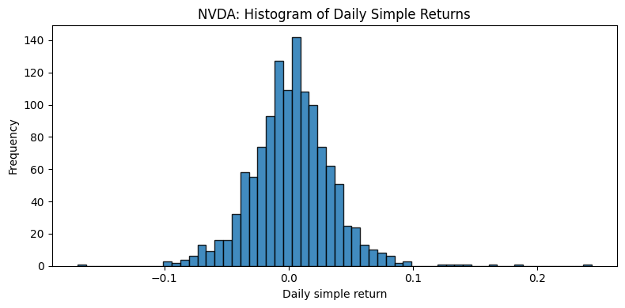

```python
# =========================
# 3) Return histogram (sanity check)
# =========================
plt.figure(figsize=(8,4))
plt.hist(df["simple_rtn"], bins=60, edgecolor="black", alpha=0.85)
plt.title(f"{TICKER}: Histogram of Daily Simple Returns")
plt.xlabel("Daily simple return")
plt.ylabel("Frequency")
plt.tight_layout()
plt.show()
```

## 4) Historical VaR — Daily

For confidence level (c), **daily historical VaR** is the empirical ((1-c)) quantile of daily returns.

- 95% VaR → 5th percentile of daily returns
- 99% VaR → 1st percentile of daily returns

We also compute **Dollar VaR** for an initial investment value.

```python
# =========================
# 4) Historical VaR (Daily)
# =========================
results_daily = []

for c in CONF_LEVELS:
    alpha = 1 - c
    var_r = np.percentile(df["simple_rtn"], 100 * alpha)   # lower tail quantile
    var_usd = INITIAL_INV * var_r

    results_daily.append({
        "Confidence": f"{int(c*100)}%",
        "Daily VaR (return)": var_r,
        "Daily VaR ($)": var_usd
    })


daily_table = pd.DataFrame(results_daily)
daily_table
```

|  | Confidence | Daily VaR (return) | Daily VaR ($) |
| --- | --- | --- | --- |
| 0 | 95% | -0.048350 | -4835.039209 |
| 1 | 99% | -0.076101 | -7610.084969 |

## 5) Historical VaR — Horizon (Rolling Compounded Returns)

A common mistake is to scale VaR by (\sqrt{T}). That is a **parametric** approximation that implicitly assumes i.i.d. Normal returns.

For **Historical VaR**, the historically consistent approach is to construct **rolling horizon returns** using compounding:

[ R_{t,t+H} = \prod_{j=1}^{H} (1 + R_{t+j}) - 1 ]

Then take the same lower‑tail quantile of these horizon returns.

```python
# =========================
# 5) Historical VaR (Horizon) via rolling compounded returns
# =========================
gross = (1 + df["simple_rtn"])

# Rolling product of gross returns over HORIZON_DAYS
rolling_gross = gross.rolling(HORIZON_DAYS).apply(np.prod, raw=True)
horizon_rtn = (rolling_gross - 1).dropna()

results_h = []
for c in CONF_LEVELS:
    alpha = 1 - c

    # <-- THIS LINE WAS MISSING
    var_h = np.percentile(horizon_rtn, 100 * alpha)

    var_h_usd = INITIAL_INV * var_h

    results_h.append({
        "Confidence": f"{int(c*100)}%",
        f"{HORIZON_DAYS}-day VaR (return)": var_h,
        f"{HORIZON_DAYS}-day VaR ($)": var_h_usd
    })

horizon_table = pd.DataFrame(results_h)
horizon_table
```

|  | Confidence | 30-day VaR (return) | 30-day VaR ($) |
| --- | --- | --- | --- |
| 0 | 95% | -0.209651 | -20965.058041 |
| 1 | 99% | -0.331554 | -33155.417599 |

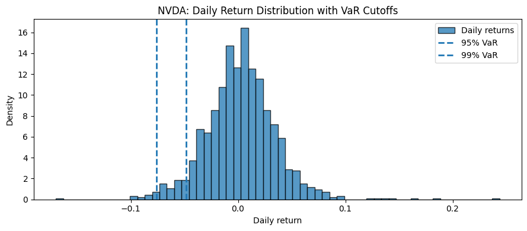

```python
# =========================
# 6) Histogram with VaR cutoffs (Daily)
# =========================

plt.figure(figsize=(9,4))

# Histogram of returns
plt.hist(df["simple_rtn"], bins=60, density=True,
         edgecolor="black", alpha=0.75, label="Daily returns")

# Plot VaR lines
for c in CONF_LEVELS:
    alpha = 1 - c
    var_r = np.percentile(df["simple_rtn"], 100 * alpha)
    plt.axvline(var_r, linestyle="--", linewidth=2,
                label=f"{int(c*100)}% VaR")

plt.title(f"{TICKER}: Daily Return Distribution with VaR Cutoffs")
plt.xlabel("Daily return")
plt.ylabel("Density")
plt.legend()
plt.tight_layout()
plt.show()
```

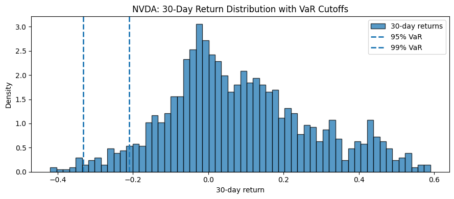

```python
# =========================
# Histogram with VaR cutoffs (Horizon)
# =========================

plt.figure(figsize=(9,4))

plt.hist(horizon_rtn, bins=60, density=True,
         edgecolor="black", alpha=0.75, label=f"{HORIZON_DAYS}-day returns")

for c in CONF_LEVELS:
    alpha = 1 - c
    var_h = np.percentile(horizon_rtn, 100 * alpha)
    plt.axvline(var_h, linestyle="--", linewidth=2,
                label=f"{int(c*100)}% VaR")

plt.title(f"{TICKER}: {HORIZON_DAYS}-Day Return Distribution with VaR Cutoffs")
plt.xlabel(f"{HORIZON_DAYS}-day return")
plt.ylabel("Density")
plt.legend()
plt.tight_layout()
plt.show()
```

## 6) Interpretation prompts (optional)

- Compare 95% vs 99% VaR. What does a higher confidence level imply?
- Compare daily VaR to horizon VaR. Why is horizon VaR larger in magnitude?
- How might the chosen sample window (START/END) affect Historical VaR?

## Appendix: Exporting your notebook (for submission)

To export with outputs visible (so the instructor does not need to re-run code):

- **HTML**: File → Save and Export Notebook As → HTML
- **PDF**: File → Save and Export Notebook As → PDF *(may require LaTeX installed)*